# EDSS & MSFCs in Epic

Antoine Lizee

05/12/2015

## Intro

The goal of this document is to investigate the EDSS in the EPIC cohort. In particular, we would like to develop an understanding of why the EDSS is predicitve of the EDSS worsening with a negative effect. The data used here is the data used in the EPIC 10 paper.

This document includes the code used for the creation of the graphs and the conclusion, but this code is hidden from the output, please see the source .Rmd file to see this code.

# EDSS

## Evolution of EDSS

Let’s simply have a look at the evolution of EDSS in the cohort as a whole. We pool all patients together and look at the dependency between EDSS and Disease Duration. The visits with patients more than 40 years into the disease, or with an EDSS greater than 7, are removed for clarity.

Below is a chart showing the data points (one per visit) in a “summed” representation: for each disease duration, the size of the point is proportional to the number of visits with the corresponding EDSS. We plotted the distribution of visits per year of disease duration in the background to show the variatio of number of visits along disease duration.

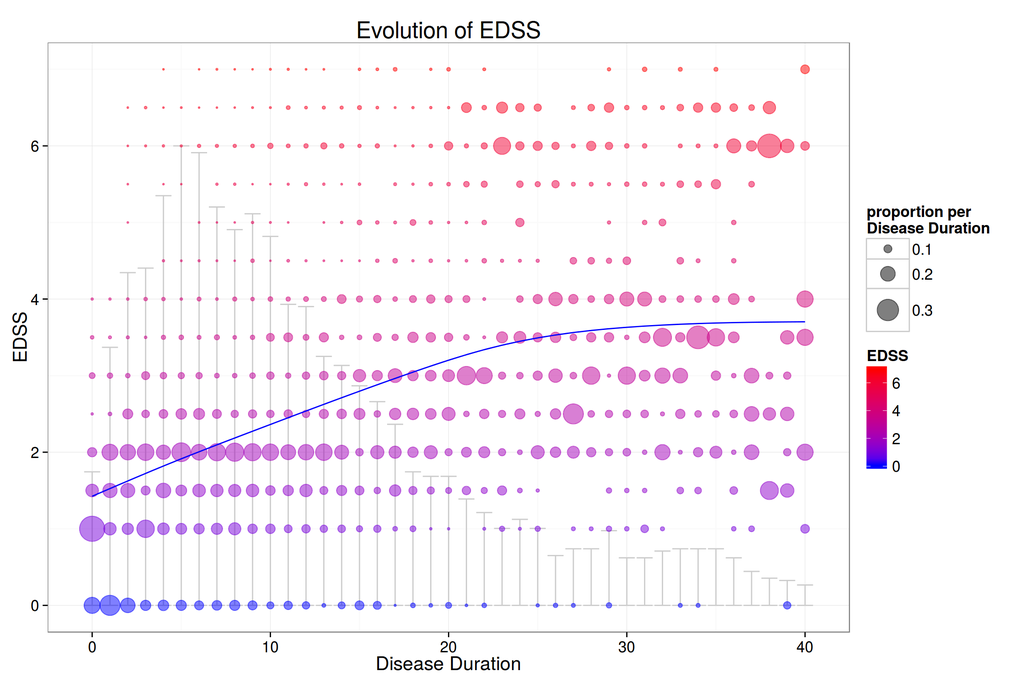

We can show another representation of the same data, where we overlay the jittered points with a series of boxplots, for each diseaseduration:

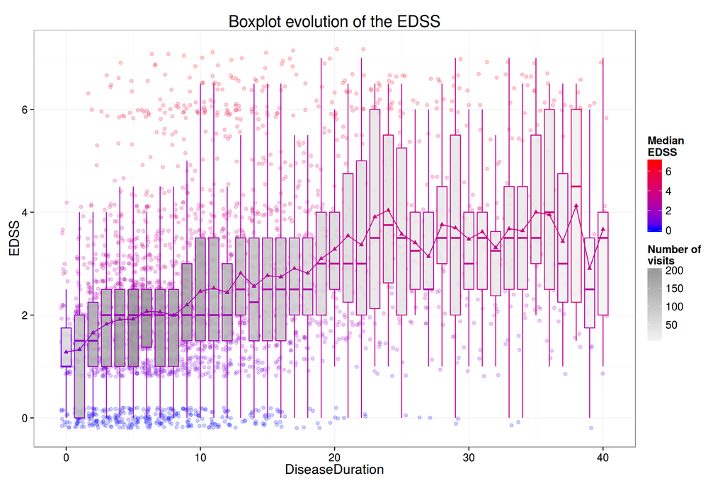

## EDSS Gradient

Here, we try to better characterize the changes in EDSS by computing, per patient, some EDSS differences.

The first approach that we will take is to compute the “gradient” of the EDSS. This quantity captures the amount of positive or negative variation of EDSS, averaged over time, between two visits:

$gEDSS = \frac{\Delta(EDSS)}{\Delta(T)} = \frac{EDSS(t+1) - EDSS(t)}{T(t+1) - T(t)}$

By computing, per patient, the different EDSS gradients between consecutive visits, we can visualise the evolution of the disease for different patients.

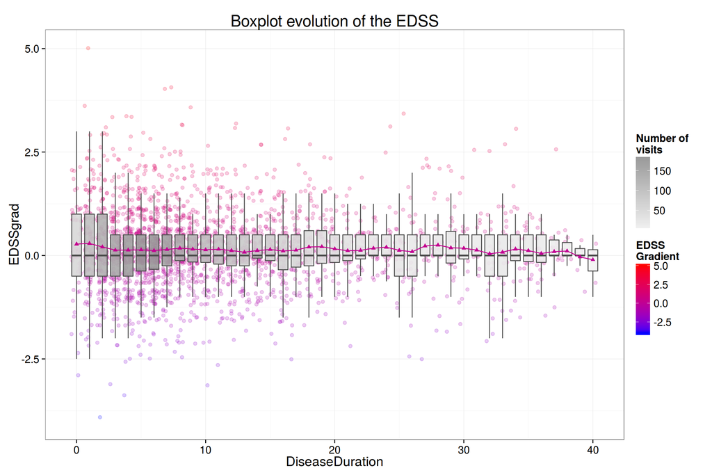

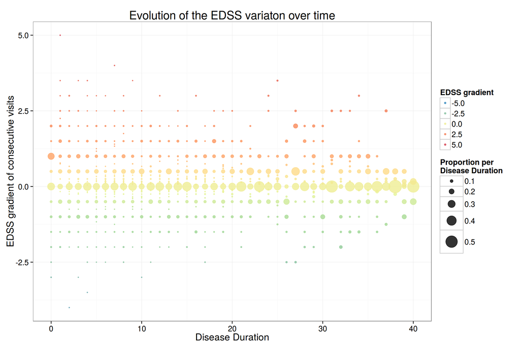

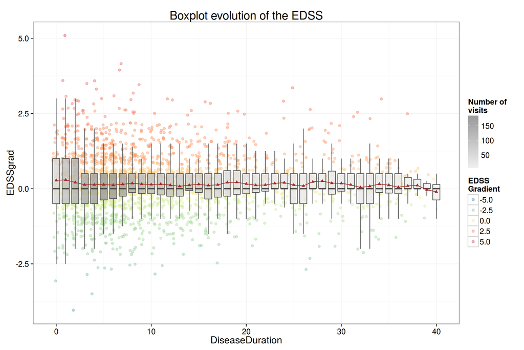

## Non-consecutive EDSS Gradient

If we don’t limit ourselves to consecutive visits, and compute the gradient for any pair of visits for each patients, we end up with many data points, that cover a larger range of disease worsening evaluation.